# 智能制造系统设计 · 第 1 讲：课程导论、工程与社会与质量工程（一）

## 737 MAX（三）：组织与监管失效

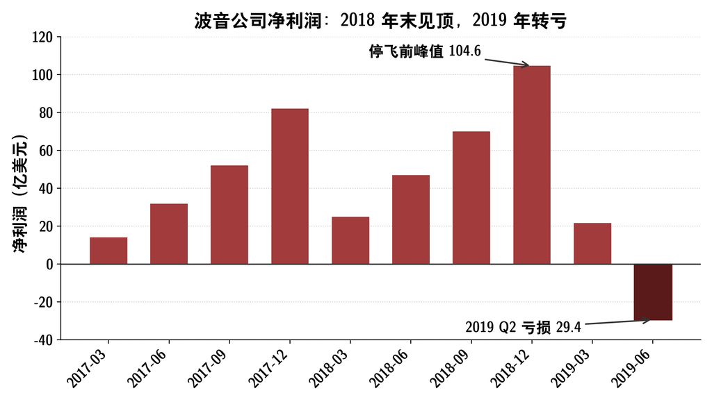

- **商业压力**：为与 A320neo 竞争，选择改型而非全新设计，压缩研制周期
- **适航验证**：FAA 将部分安全评估委托波音（ODA），MCAS 的风险被低估
- **培训与信息**：为降低航司培训成本，MCAS 未进入模拟机训练与手册
- **利益关系**：监管与被监管者之间的密切关系与人员流动，削弱独立性
- **财务后果**：停飞后利润大幅下滑；2021 年约 25 亿美元和解
- **组织教训**：合规由被监管者自己证明时，合规就不再是安全证据
- 一句话：**技术缺陷可以修，制度缺陷会不断制造新的技术缺陷**

## 两个案例对比：凯悦与 737 MAX

| 维度 | 凯悦（1981） | 737 MAX（2018—2019） | 共同点 |
| --- | --- | --- | --- |
| 失效性质 | 结构连接失效 | 飞控软件逻辑失效 | 单点失效被放大 |
| 触发环节 | 施工变更绕过复核 | 设计变更绕过独立验证 | 变更未回到计算与复核 |
| 组织因素 | 业主压成本、设计方过度信任分包商 | 商业进度压过工程判断、监管外包 | 组织压力压过工程判断 |
| 监管角色 | 建筑规范与审查范围被合同限定 | FAA 将部分适航评估委托波音 | 监管边界被商业利益挤占 |
| 后果 | 114 死 216 伤；执照吊销；约 1.4 亿美元 | 346 死；停飞约 20 个月；约 25 亿美元 | 代价由顾客与社会承担 |

- 同：都是“**变更或简化 → 未独立复核 → 组织压力**”的剧本，不是“技术不会算”
- 异：凯悦是“人—图纸”链条，737 MAX 是“软件—组织—监管”链条，后者更隐蔽、更难追责
- 一句话：事故的形态在变，**责任的结构没有变**

## 五大工具各防什么：事故给出的分工

| 工具 | 防什么 | 对应事故断点 | 跳过的后果 |
| --- | --- | --- | --- |
| APQP & CP | 策划与现场控制点缺失 | 变更后没有更新控制计划 | 关键特性没人管 |
| FMEA | 失效模式与后果未被预见 | 连接处荷载翻倍未被识别 | 风险靠运气发现 |
| MSA | 测量数据不可信 | 数据不准导致误判 | 后面所有结论作废 |
| SPC | 过程异常未及时发现 | 前兆信号被忽略 | 异常流到顾客 |
| PPAP | 量产前未验证能力 | 变更未经批准就量产 | 批量风险失控 |

- 五大工具是一条**证据链**：前一环的输出是后一环的输入，缺一环证据链就断
- 工具的顺序 = 风险发生的时间顺序：策划 → 预见 → 测量 → 监控 → 批准
- 判据：每个工具都要能回答“如果没做，最坏会怎样”

## 把“人可能犯错”变成“系统不易犯错”

- 人一定会犯错：疲劳、疏忽、沟通偏差、时间压力——这是**常量**，不是可消除的变量
- 工具的三种作用：**防错**（不让错发生）、**探测**（错了能发现）、**隔离**（发现后不流出）
- FMEA 把“没想到”变成“写下来”；控制计划把“写下来”变成“现场怎么做”
- MSA 让数据可信；SPC 让异常可见；PPAP 让能力可证
- 社会意义：工具是**把一次事故的制度记忆固化成流程**——后人不必亲历事故，也能继承教训
- 反例：把工具当“交差文件”，等于把事故的记忆格式化
- 一句话：**把“人可能犯错”变成“系统不易犯错”**

## 质量文化：从罚款文化到学习文化

| 文化类型 | 核心问题 | 典型行为 | 结果 |
| --- | --- | --- | --- |
| 罚款文化 | 谁的责任？ | 隐瞒、推责、删记录 | 同类事故重复发生 |
| 合规文化 | 有没有按文件做？ | 补文件、走过场 | 合规但不安全 |
| 学习文化 | 哪个环节失效？ | 报告、复盘、改流程 | 事故率持续下降 |

- 文化的三个判据：坏消息能不能上传？报告会不会被惩罚？改进有没有闭环？
- 凯悦的“电话之争”是罚款文化：先争“谁同意过”，而不是“怎样能拦住”
- 工具落地：8D 的 D7“预防再发”、FMEA 持续更新、变更管理、无责备报告制度
- 一句话：文化的标志不是“没有事故”，而是“**事故前有人说得出、事故后有人改得动**”

## 伦理主线的 6 课时地图

- **6 课时 = 第 1 讲 1 + 第 8 讲 2 + 第 9 讲 2 + 第 10 讲 1**；不是附加章，而是贯穿全课的分析视角

| 课时 | 落在哪一讲 | 主题 | 可考核能力 |
| --- | --- | --- | --- |
| 1 | 第 1 讲（内容块 2、4） | 工程与社会导论；质量的社会责任 | 用社会契约与可预见性分析质量决策 |
| 2—3 | 第 8 讲 | 工程事故与伦理准则、决策框架 | 用三框架分析一个事故 |
| 4—5 | 第 9 讲 | 风险、安全、责任与组织 | 判定责任类型、设计组织防线 |
| 6 | 第 10 讲（内容块 1–2） | 技术的社会意义、AI 伦理 | 写出完整伦理分析章 |

- **三步分析框架**：① 利益相关方与影响分析 → ② 伦理问题识别与定位 → ③ 伦理决策与辩护
- 考试落点：论述题“结合案例”必用；课程设计伦理章必用

## 课程设计要求：伦理与社会影响分析章

- **独立成章**：技术方案之外单独一章，不并入技术章节；课程设计答辩必须汇报
- **四节结构**：① 对象与利益相关方 ② 影响清单与伦理定位 ③ 决策辩护与替代方案 ④ 结论与自查
- 三步框架要落到**具体参数**：谁受影响、影响多大、依据哪条规范或准则
- 准则依据：**NSPE 伦理准则第 1 条**——工程师的首要义务是保护公众的安全、健康与福祉
- 答辩要求：单独汇报这一章，必答“如果成本翻倍，你还坚持这个方案吗”
- 评分看三点：**事实准确、框架完整、辩护有力**；不看口号喊得响不响
- 常见失分：写成社会责任口号、只列影响不给判断、没有替代方案

## 中国重大质量安全事件：四案四教训

**四起事件，行业不同，剧本几乎相同：预警被绕过、记录被造假、监管被架空。**

| 事件 | 时间 | 关键事实 | 制度回应 |
| --- | --- | --- | --- |
| 三聚氰胺奶粉 | 2008 | 累计报告患儿 29.4 万人、住院 5.19 万人 | 取消食品免检；限量 1 mg/kg；《食品安全法》2009 年施行 |
| 天津港爆炸 | 2015 | 165 人遇难（救援人员 110 人）、798 人受伤、损失 68.66 亿元 | 认定特别重大生产安全责任事故；危化品监管改革 |
| 长生疫苗 | 2018 | 狂犬病疫苗生产记录造假、百白破疫苗效价不合格 | 罚没 91 亿元、强制退市；《疫苗管理法》2019 年 12 月施行 |
| 响水爆炸 | 2019 | 78 人死亡、76 人重伤、损失 19.86 亿元 | 认定长期违法贮存硝化废料；危废监管加严 |

- 共同点：都不是“某个坏人”能单独造成的，而是企业、中介、监管三道防线同时失效
- 判据：看事故前有没有人“说过”，事故后有没有人“改得动”
- 一句话：**事故的剧本几乎相同，只是行业不同**

## 质量强国战略：从三个转变到纲要

**把质量从企业行为上升为国家战略，是因为质量影响出口议价、产业升级与公共安全，单个企业做不到。**

- 三个转变（2014）：中国制造向中国创造转变、中国速度向中国质量转变、中国产品向中国品牌转变
- 《质量强国建设纲要》2023 年 2 月印发，分 2025、2035 两步走：先补短板，再上水平
- 四个抓手：质量基础设施（计量、标准、认证认可、检验检测）、质量提升行动、首席质量官、质量奖与品牌
- 判据：看三个可测的量——制造业质量竞争力、消费品抽查合格率、出口退运与召回频次
- 与个人的关系：战略的最后落点是一条焊缝、一次校准、一份真实记录
- 一句话：**质量强国不是口号，是把“合格”变成“可信”**

## 质量信用与黑名单：让失信有成本

**信用监管的逻辑：把一次性的罚款，变成对未来交易资格的影响。**

| 工具 | 内容 | 判据 |
| --- | --- | --- |
| 信用档案 | 许可、处罚、抽检、投诉记录 | 是否完整、可查询、可更正 |
| 严重违法失信名单 | 主观故意、后果严重、屡犯者列入 | 列入条件法定、公示期明确 |
| 联合惩戒 | 融资、招投标、政府采购受限 | 措施与失信程度相当 |
| 信用修复 | 履行义务、消除影响后申请移出 | 有程序、有期限、可救济 |

- 为什么：罚款若被当作“经营成本”，就失去威慑；信用惩罚打在“未来机会”上
- 边界：不能“以信代法”——列入要有依据，移出要有通道，异议与复议要能用
- 一句话：**让守信者一路畅通、失信者处处受限，前提是程序正义**

## 召回制度：汽车、食品与药品三条线

**召回是缺陷产品从消费者手里收回来的法定机制：主动召回是止损，隐瞒才是加倍损失。**

| 领域 | 主要依据 | 分级与时限 | 判据 |
| --- | --- | --- | --- |
| 汽车 | 《缺陷汽车产品召回管理条例》，2013 年施行 | 生产者报告、缺陷调查、责令召回 | 是否主动、范围是否准确 |
| 食品 | 《食品召回管理办法》 | 一级 24 小时、二级 48 小时、三级 72 小时内启动 | 是否停止生产、是否告知消费者 |
| 药品 | 《药品召回管理办法》，2022 年修订 | 三级召回，24／48／72 小时内通知 | 是否可追溯、是否收回销毁 |

- 为什么分级：危害越急，留给企业的时间越短；时限是社会可接受的速度，不是企业的方便
- 经济学：召回成本远小于隐瞒被发现的成本（信任、罚没、退市）
- 判据：召回四个动作——停、告、收、改，缺一项就是“假召回”
- 一句话：**召回不是丑闻，隐瞒才是**

## 质量事故问责：四不放过与终身追责

**问责的目的不是找替罪羊，而是让“下一次有人敢说不”。**

- 事故分级（生产安全事故报告和调查处理条例）：特别重大 30 人以上死亡、重大 10—29 人、较大 3—9 人、一般 3 人以下
- 四不放过：原因未查清不放过、责任未落实不放过、整改未完成不放过、有关人员未受教育不放过
- 责任类型：直接责任、主要责任、领导责任；党政同责、一岗双责、终身追责
- 天津港的问责刻度：对 123 名责任人员提出处理意见，74 名受党纪政纪处分（含省部级 5 人）；24 名企业人员、25 名监察对象被立案侦查
- 判据：问责是否“到岗到人”——有没有签字权、审批权、否决权；是否“以罚代管”
- 一句话：**问责要问出“制度漏洞”，而不只是“个人过失”**

## 消费者权益保护：让维权划得来

**当单个消费者的损失远小于维权成本时，市场约束就失效——惩罚性赔偿就是把这个账改过来。**

| 工具 | 内容 | 适用条件 |
| --- | --- | --- |
| 三包与七日无理由退货 | 修理、更换、退货；网购七日无理由 | 定作、鲜活、数字化商品等除外 |
| 惩罚性赔偿（消法） | 退一赔三，不足 500 元按 500 元 | 经营者有欺诈行为 |
| 惩罚性赔偿（食品安全法） | 十倍价款或三倍损失，不足 1000 元按 1000 元 | 不符合食品安全标准 |
| 投诉与公益诉讼 | 12315、消协、检察公益诉讼 | 群体性损害 |

- 为什么有效：让“企业算错的账”被改对——违法收益小于赔偿成本，才有威慑
- 判据：是否欺诈（主观）、是否明知（食品）、是否造成实际损害
- 局限：举证难、周期长；群体性损害更依赖行政监管与公益诉讼
- 一句话：**让维权划得来，质量才有市场约束力**

## 工程质量终身责任制：签字的人一直在

**工程寿命五十年以上，而参与人几年就流动——只有“责任跟人走”，才能对抗“任期制”。**

- 五方责任主体：建设、勘察、设计、施工、监理的项目负责人，对设计使用年限内的质量负终身责任
- 三项制度：责任人信息档案、竣工永久性标牌（载明五方与负责人姓名）、质量终身责任追究
- 为什么：结构安全问题的暴露期可能长达几十年，事后追责必须有“可追溯的人”
- 判据：有没有签字、有没有标牌、有没有档案；重大变更有没有重新审批与重新签章
- 局限：单位注销、人员退休后的追责难；与建筑师负责制、工程保险如何衔接仍在探索
- 一句话：**终身责任制的本质，是把“未来”拉到“现在”来做决定**

## 质量伦理的国际比较：四种路径

**没有唯一正确的模式，只有与本国法律、产业阶段匹配的模式。**

| 路径 | 主要机制 | 文化基础 | 局限 |
| --- | --- | --- | --- |
| 美国 | 职业准则（NSPE）＋执照（PE）＋惩罚性赔偿＋判例 | 专业自治、契约与诉讼 | 诉讼成本高，预防不足 |
| 日本 | TQC、戴明奖（1951）、现场主义、长期雇佣 | 持续改进、团队与供应商系列 | 供应链封闭，追责偏慢 |
| 德国 | DIN 标准、双元制、行业协会 | 标准意识、学徒传统 | 标准更新慢，转型成本高 |
| 中国 | 政府监管＋信用惩戒＋质量强国战略＋专项整治 | 集中治理、后发追赶 | 运动式治理易反弹 |

- 历史注脚：1887 年英国要求德国产品标注“德国制造”，本意是区分劣质品；德国用标准与工艺把这个标签做成了信誉
- 判据：看三件事——谁定义标准、谁监督执行、出事谁赔
- 一句话：**比较制度，不如比较它解决了哪个问题**

## 企业质量文化：丰田、华为、海尔

**文化不是墙上的标语，是“停线按钮”离工人有多远。**

| 企业 | 公开做法 | 判据／代价 |
| --- | --- | --- |
| 丰田 | 自働化（安灯拉绳停线）、准时化、5Why、现地现物 | 一线有停线权；但 2009—2010 年大规模召回暴露规模扩张对文化的侵蚀 |
| 华为 | 1998 年起引入 IBM 的 IPD 变革（其后是 ISC），“先僵化、后优化、再固化” | 把个人经验变成组织能力；代价是短期效率与抵触 |
| 海尔 | 1985 年当众砸毁 76 台不合格冰箱；OEC“日事日毕、日清日高” | 用一次极端事件立规矩，靠日清维持 |

- 三条判据：坏消息能不能上传、停线权在谁手里、质量指标能不能否决发货
- 为什么“砸冰箱”有效：把抽象的质量承诺变成看得见的代价，从此“差不多”不再被接受
- 反例：文化写在墙上，考核只考产量——员工很快学会“质量是口号”
- 一句话：**文化看行为，不看口号**

## 质量与国家安全：看不见的国防

**质量基础设施（计量、标准、认证认可、检验检测）是国家能力，不只是企业能力。**

- 三个层面：计量基标准（能不能自己校准）、标准与认证（能不能自己定规则）、关键件与仪器（有没有备份供应）
- 为什么上升到安全：基础件与材料的质量差距会沿产业链放大成装备可靠性问题；标准与认证是国际贸易的技术壁垒
- 例：高端轴承、精密仪器、工业软件、芯片——不是“造不出样品”，而是“批量一致性不够”
- 判据：关键件有没有二供、关键参数能不能自校准、国际标准里有没有中国提案
- 《计量发展规划（2021—2035 年）》把计量基标准列为国家战略资源
- 与个人的关系：你写的每一个公差、每一份试验数据，都在给国家的可信度投票
- 一句话：**质量安全是看不见的国防**

## 质量舆情治理：补回信任存量

**质量事件的舆论演化 = 事实 × 情绪 × 信任存量；信任存量低时，真话也会被怀疑。**

| 阶段 | 舆论特征 | 处置要点 |
| --- | --- | --- |
| 曝光 | 信息碎片、真假混杂 | 快速确认事实边界，先讲已知与未知 |
| 发酵 | 归因与情绪主导，旧账被翻出 | 责任到人、措施可验证，不做“临时工”式回应 |
| 处置 | 关注度下降，信任待修复 | 第三方检测、开放工厂、追溯码、定期通报 |

- 四问自检：事实是否可核查、责任是否到人、措施是否可验证、受害者是否被安置
- 三个陷阱：删帖与沉默（放大猜测）、只讲态度不讲数据、承诺无法验证
- 建设性做法：吹哨人保护、第三方复核、把整改过程公开成“可查的进度表”
- 一句话：**舆情治理的目标不是压下去，是把信任存量补回来**

## 课程设计选题示例：六个可做的题目

**好选题的判据：有争议、有数据、有可查的规范——三者缺一，写出来就是空话。**

- ①动力电池热失控预警：阈值定多少，误报与漏报的代价各由谁承担
- ②一体化压铸件缺陷追溯：从 X 光片到批次，一次召回演练怎么把范围缩到最小
- ③产线视觉检测：算法偏差与员工影像采集的隐私边界
- ④供应商擅自更换材料：来料检验、变更申报与责任链是怎么断的
- ⑤汽车 OTA 升级：这算“召回”还是“服务”，监管与用户知情怎么落地
- ⑥医疗器械或食品批次追溯：记什么、留多久、谁能看——追溯系统的伦理设计
- 交付与评分：一章正文 + 10 分钟答辩 + 一张利益相关者图；看事实准确、框架完整、辩护有力
- 一句话：**好选题，是能让你在两个都对的答案之间做选择**

## 推导留给 AI：质量的社会责任

- 查证凯悦酒店事故的完整时间线与责任判定，列出三个“本可以避免”的环节。
- 737 MAX 的 MCAS 设计涉及哪些工程与组织因素？用“可预见性/可控制性”分析责任。
- “安全事故”与“安全责任事故”的判定在我国法律法规中如何体现？举例说明。
- 质量成本四类中，哪一类最容易被“省掉”？省掉的后果是什么？
- 用三步分析框架，对“某产品参数接近上限仍放行”做一次完整分析。

# 第五部分 · 例题、讨论与 AI 提问

- 历年真题与给分结构：概念、体系、五大工具、Cpk 判读
- 课堂讨论：质量定义、七项原则、社会实验四问
- 计算例题：质量成本、ppm 换算、投资回收期——每题“题干＋分步解答”两页
- 开放问题：AI 时代工程师的能力结构；考前自测
- **承上**：前面四个内容块给了概念与案例；本部分要回答“这些知识怎么考、怎么讨论、怎么向 AI 追问”。

## 历年真题（一）：概念与体系

**单选（2022 A 卷第 5 题，另一版为第 6 题）** 下面不属于质量体系五大工具的是（ ） A. APQP B. SPC C. FMEA D. SWOT

- 答案 **D**：SWOT 是战略分析工具；五大工具 = APQP & CP、FMEA、MSA、SPC、PPAP

**单选（2020 B 卷第 5 题）** 下面属于质量管理认证体系的是（ ） A. ISO 9000 B. ISO 14000 C. OHSAS 18000 D. ISO 27001

- 答案 **A**：ISO 9000 族是质量管理体系；14000 环境、45001 职业健康、27001 信息安全。严格说，可认证的是族中的 ISO 9001

**简答（多卷）** 列举智能制造系统的 5 个组成（如 APS）并简述功能

- ERP（资源计划）、MES（制造执行）、PLM（产品生命周期）、CRM（客户关系）、WMS（仓储管理）、APS（高级排程）任选五个

## 开放问题：AI 时代工程师的能力结构

- 当 AI 能写代码、画图、做仿真、查标准时，工程师的核心竞争力是什么？
- **提出好问题**：AI 擅长给答案，不擅长定义问题——本课程的“推导留给 AI”就是训练提问
- **判断与负责**：AI 不能签字、不能担责，最终决策与责任仍在工程师
- **跨领域整合**：把质量、成本、安全、伦理放在同一张图上看
- **沟通与说服**：把技术结论讲给不同的人听

> 一句话：**AI 时代，工程师的价值从“算得对”转向“问得对、判得准、担得起”。**

## 历年真题（二）：简答与论述题分布

- 三届六卷结构一致：单选 30 分、简答 30 分、论述 30 分、计算 10 分；与第 1、2 讲相关的考点如下：

| 题型与分值 | 考点 | 出现卷次 |
| --- | --- | --- |
| 简答 5 分 | 智能制造系统组成（如 APS） | 2020 A/B、2021 A/B、2022 B |
| 单选 3 分 | 五大工具或体系认证 | 六卷（2020—2022） |
| 简答 5 分 | 五大工具并简述内容 | 2020 B、2021 A、2022 A（9 题版） |
| 单选 3 分 | Cpk=1.45 的判读 | 六卷（2020—2022） |
| 论述 10 分 | 人机料法环画鱼骨图 | 六卷（2020—2022） |

## 历年真题（三）：五大工具与体系题解析

- **简答（2020 B 第 7 题、2021 A 第 5 题、2022 A 第 8 题（9 题版），5 分）**：列举质量体系五大工具并简述其内容
- **单选（2022 A 第 5 题，另一版第 6 题；3 分）**：不属于五大工具的是——SWOT
- **单选（2020 B 第 5 题，3 分）**：属于质量管理认证体系的是——ISO 9000
- 简答给分：5 个工具 × 1 分 ＝ 名称 0.5 分 ＋ 一句话功能 0.5 分
- 名字与功能：APQP & CP（策划与控制计划）、FMEA（失效模式与后果）、MSA（测量系统）、SPC（统计过程控制）、PPAP（生产件批准）
- 常见错误：APQP 与 PPAP 写混、漏掉 CP、把 8D 或 QC 七大手法当五大工具
- 体系题：ISO 9001 质量、ISO 14001 环境、ISO 45001 职业健康、ISO 27001 信息安全

## 历年真题（四）：Cpk 1.45 的判读定位

- **题干（2020—2022 六卷同题，单选 3 分）**：过程能力指数 $C_{pk}=1.45$ 代表（ ）
- A. 无缺点、可考虑降低成本 B. 状态良好、维持现状 C. 改进为 A 级 D. 制程不良较多

| 等级 | Cpk 范围 | 处理原则 |
| --- | --- | --- |
| A+ | ≥ 1.67 | 能力富余，可考虑降成本 |
| A | 1.33 ≤ Cpk < 1.67 | 状态良好，保持现状 |
| B | 1.00 ≤ Cpk < 1.33 | 需改进至 A 级 |
| C | 0.67 ≤ Cpk < 1.00 | 不良较多，必须提升 |
| D | < 0.67 | 能力严重不足，重新设计 |

- $1.45\in[1.33,1.67)$ → **A 级 → 答案 B**
- 换算校验：$Z=3\times1.45=4.35$，双侧约 **13.6 ppm**——不是“无缺点”
- 判读前提：过程受控、测量系统可信；两个陷阱——把 B 级的“改进至 A 级”误当成 1.45，把 A+ 的“降成本”提前用

## 真题答案要点：简答题的给分结构

- **5 分简答 ＝ 1 分定义 ＋ 3 分要点 ＋ 1 分例子**（或 2 ＋ 2 ＋ 1）
- 以“五大工具”为例：5 个工具名（1 分）＋ 5 句功能（3 分）＋ 1 个使用场景（1 分）
- 以“系统组成”为例：5 个模块名（1 分）＋ 各自功能（3 分）＋ 与制造流程的关系（1 分）
- **10 分论述 ＝ 概念（2）＋ 分析（4）＋ 案例（3）＋ 结论（1）**
- 以“质量是社会责任”为例：定义质量（2）→ 四方代价与责任判定（4）→ 凯悦或 737 MAX（3）→ 结论（1）
- 阅卷偏好：分点、术语准确、每段有“所以”；反例：只写名词不解释、堆例子无概念
- 一句话：**先说清“是什么”，再说“为什么”，最后说“所以呢”**

## 课堂讨论 1：质量定义辨析（答案版）

- **判断下列 6 条属于“明确需求”还是“隐含需求”，并说明依据：**

| 判断 | 例子 | 依据 |
| --- | --- | --- |
| 明确 | ① 合同规定产品寿命 ≥ 5 年 | 写入合同，有法律约束力 |
| 隐含 | ② 顾客预期产品“不会漏电” | 未写进合同，但属安全底线 |
| 明确 | ③ 图纸标注尺寸公差 ±0.02 mm | 图纸是受控技术文件 |
| 隐含 | ④ 用户希望包装“容易打开” | 体验类需求，常被忽略 |
| 明确 | ⑤ 法规要求儿童玩具不得有小零件 | 法规强制，等同规定要求 |
| 隐含 | ⑥ 客户希望“出了问题能马上找到人” | 服务响应类需求 |

- 讨论：为什么“隐含需求”更难识别？工程师靠什么识别它？
- 识别四问：谁在用？什么场景？失效后果多严重？行业惯例与法规要求是什么？

## 课堂讨论 2：七个反例里的七项原则

**下列七个现场反例，各违反了哪一项原则？应补上什么证据？**

| # | 反例 | 被违反的原则 | 应补的证据 |
| --- | --- | --- | --- |
| A | 客诉只统计不分析 | 以顾客为关注焦点 | 客诉分类与变更单 |
| B | 质量目标质量部单定 | 领导作用 | 质量目标评审纪要 |
| C | 提案三个月无人回复 | 全员参与 | 提案闭环台账 |
| D | 出事先罚操作工 | 过程方法 | 流程与接口责任表 |
| E | 同一不良三年只返工 | 改进 | 8D 或复盘报告 |
| F | 停线凭经验拍板 | 循证决策 | 控制图与停线判据 |
| G | 供应商只压价 | 关系管理 | 质量协议与联合改进 |

- 追问：七个反例中，哪一个是“制度问题”而不是“人的问题”？为什么？
- 一句话：原则不是口号，而是“出问题时先看哪里”的检查表

## 课堂讨论 3：社会实验四问（含模板）

- **情境**：某车企把新电池包首次装车，交付 5000 辆；热失控概率未知，但仿真与台架试验通过
- 问题一：这个“实验”的实验对象是谁？他们知情吗？
- 问题二：结果的不确定性来自哪里——材料、工艺、使用场景还是算法？
- 问题三：如果发生热失控，谁承担代价？企业、车主，还是充电桩所在社区？
- 问题四：工程师能做什么，把“实验”的风险降到可接受？
- 提示：用“可预见性 × 可控制性”给每个问题打分，再写出三条设计措施
- 分析模板：对象 → 知情 → 不确定性 → 代价 → 措施（一行写一项）
- 结论：工程是实验，但实验对象没有签知情同意书——所以工程师要替他们做“最坏情况设计”

## 例题：质量成本投入决策 —— 题干与思路

**这题练什么**：判断一笔预防投入该不该花——算清年节省、净收益与回收期，再找“降多少才值得投”的阈值。

| 已知项 | 数值 | 说明 |
| --- | --- | --- |
| 年外部损失成本 $L$ | 1000 万元／年 | 赔偿、召回、品牌与安全代价的折合 |
| 新增预防投入 $I$ | 50 万元／年 | 防错装置、培训与首件检验费用 |
| 外部损失降幅 $k$ | 30% | 按年外部损失计，即 $k=0.30$ |

**求**：① 年节省 $\Delta L$（万元／年，整数）；② 净收益 $N$（万元／年，整数）与投入产出比 $B$（1 位小数）；③ 回收期 $P_t$（年，2 位小数并折成月）。

$$\Delta L=Lk,\qquad N=\Delta L-I,\qquad B=\Delta L/I,\qquad P_t=I/\Delta L$$

符号：$\Delta L$ 年节省／（万元·年⁻¹），$N$ 年净收益／（万元·年⁻¹），$B$ 投产比／无量纲，$P_t$ 回收期／年（$L$、$I$ 单位见表，$k$ 无量纲）。

**解题路线**：① 算年节省 $\Delta L=Lk$ → ② 扣投入得 $N=\Delta L-I$ → ③ 算投产比 $B$ 与回收期 $P_t$ 并折月 → ④ 反算阈值 $k_{\min}=I/L$，与 $k$ 比较下结论。

## 例题：质量成本投入决策 —— 分步解答

- **第 1 步 求年节省**：$\Delta L=Lk=1000\times0.30=300$ 万元／年；中间量：投入后年外部损失 $L'=1000-300=700$ 万元／年。
- **第 2 步 求净收益**：$N=\Delta L-I=300-50=250$ 万元／年。
- **第 3 步 求投入产出比**：$B=\Delta L/I=300/50=6.0$——每投 1 元预防费，当年收回 6 元损失。
- **第 4 步 求回收期**：$P_t=I/\Delta L=50/300\approx0.167$ 年，折合 $0.167\times12\approx2.0$ 个月。

**判读**：投入后每年净赚 250 万元、约 2 个月回本；决策阈值 $k_{\min}=I/L=50/1000=5\%$，本题降幅 30% 远超阈值，投入划算。

## 例题：缺陷率与 ppm 换算 —— 题干与思路

**这题练什么**：把过程能力指数 $C_{pk}$ 翻成缺陷率与年不良件数——能力报告上的一个数，到底对应多少件坏品。

| 已知条件 | 数值 | 说明 |
| --- | --- | --- |
| 过程能力指数 $C_{pk}$ | 1.45 | 过程受控、均值与规格中心重合 |
| 年产量 $N$ | 100 万件／年 | 用于把 ppm 换成件数 |

**求**：① $Z=3C_{pk}$（无量纲，2 位小数）；② 单侧、双侧缺陷率（ppm）与合格率（%，5 位小数）；③ 年产 100 万件的不良件数（件，向上取整），并给出 $C_{pk}=1.33$ 时的对比。

$$\Phi(-Z)=1-\Phi(Z),\qquad p_{\text{单}}=\Phi(-Z),\qquad p_{\text{双}}=2\Phi(-Z),\qquad \text{ppm}=p\times10^{6}$$

符号：$Z$ 为规格上限到均值的标准差倍数（无量纲），$\Phi(\cdot)$ 为标准正态分布函数，$p$ 为缺陷率（无量纲），ppm 为百万分之缺陷数（$10^{-6}$）。

**解题路线**：① 由 $C_{pk}$ 求 $Z$ → ② 查 $\Phi(-Z)$ 得单侧、乘 2 得双侧 → ③ 换 ppm 与合格率 → ④ 乘年产量得件数，再换 1.33 对比。

## 例题：缺陷率与 ppm 换算 —— 分步解答

- **第 1 步 求 Z 值**：中心重合时 $Z=(\text{USL}-\mu)/\sigma=3C_{pk}=3\times1.45=4.35$（无量纲）。
- **第 2 步 求单侧缺陷率**：$\Phi(-4.35)=6.807\times10^{-6}$，即 $p_{\text{单}}\approx6.81$ ppm（另一侧同值）。
- **第 3 步 求双侧缺陷率与合格率**：$p_{\text{双}}=2\times6.807\times10^{-6}=1.361\times10^{-5}$（13.6 ppm），合格率 $=1-p_{\text{双}}=99.99864\%$。
- **第 4 步 换算件数并对比**：$n=N\,p_{\text{双}}=10^{6}\times1.361\times10^{-5}=13.6$ 件，向上取整 **14 件**；$C_{pk}=1.33$ 时 $Z=3.99$，约 66 件（66 ppm）。

**判读**：$C_{pk}=1.45$ 属 A 级“过程状态良好”，但仍有约 13.6 ppm 缺陷；能力降到 1.33（仍算及格）后，年不良件数从 14 件涨到 66 件，约 4.8 倍。

**易错点/验算**：① 忘乘 2 会把双侧 13.6 ppm 写成单侧 6.8 ppm；② ppm 与 % 差 $10^{4}$ 倍，13.6 ppm＝0.00136%；③ 验算 $1.361\times10^{-5}\times10^{6}=13.6$，与合格率 99.99864% 互补。

## 例题：投资回收期 —— 题干与思路

**这题练什么**：把一次性投资与每年净收益放到时间轴上，算“几年回本”，再用基准与敏感性判断投不投。

| 已知项 | 数值 | 说明 |
| --- | --- | --- |
| 初始投资 $I_0$ | 240 万元 | 第 0 年一次性支出，系统安装与调试 |
| 年净收益 $A$ | 60 万元／年 | 已扣除运行维护费，第 1 年起每年相同 |
| 基准回收期 $P_c$ | 5 年 | 超过 5 年判定不可行 |

**求**：① 静态回收期 $P_t$（年，2 位小数）；② 逐年累计现金流（万元）与回本年份；③ 按 $P_c=5$ 年判可行性，并给出 $A'=45$ 万元／年时的结论。

$$P_t=\frac{I_0}{A},\qquad C_t=-I_0+tA,\qquad P_t=(m-1)+\frac{|C_{m-1}|}{A}$$

符号：$I_0$ 初始投资／万元，$A$ 年净收益／（万元·年⁻¹），$P_t$ 静态回收期／年，$C_t$ 第 $t$ 年末累计现金流／万元，$m$ 累计现金流首次非负的年份。

**解题路线**：① 用 $P_t=I_0/A$ 求回收期 → ② 逐年列 $C_t$ 找回本年 → ③ 与 $P_c$ 比较 → ④ 换 $A'=45$ 万元／年复算并下结论。

## 例题：投资回收期 —— 分步解答

- **第 1 步 求静态回收期**：$P_t=I_0/A=240/60=4.00$ 年。
- **第 2 步 列逐年累计现金流**：$C_0=-240$、$C_1=-180$、$C_2=-120$、$C_3=-60$、$C_4=0$（万元），第 4 年末归零，回本年 $m=4$。
- **第 3 步 与基准比较**：$P_t=4.00\le P_c=5$ → **可行**；若 $P_c=3$ 年，则 $4>3$ → 不可行。
- **第 4 步 敏感性分析**：$A'=45$ 万元／年 → $P_t'=240/45\approx5.33$ 年 $>5$ 年 → **不可行**。

**判读**：回收期只看“多久回本”，不看回本后还能赚多少，也不折现；年净收益从 60 降到 45（降 25%），结论就从可行翻成不可行。

**易错点/验算**：① 投资额只在第 0 年算一次，别按年摊进分母；② 累计现金流不在整数年归零时用插值 $P_t=(m-1)+|C_{m-1}|/A$；③ 验算 $4\times60=240$ 万元＝初始投资。

## AI 提问：本讲 5 个延伸问题

- 用事故树（FTA）把凯悦案画成一棵故障树，求最小割集，并说明哪些割集对应“制度断点”。
- 把 737 MAX 的 MCAS 写成一张 FMEA 表（失效模式、后果、严重度、频度、探测度、RPN），再论证“单一传感器”的探测度为何被低估。
- 查证《生产安全事故报告和调查处理条例》的事故等级划分，并映射到“责任事故”的判定。
- 用质量成本模型估算：预防投入从 1% 提到 3%，什么条件下净收益为正？生命价值能否货币化？
- 让 AI 生成一份“质量伦理”课程设计选题清单，再用三步框架逐条评估可行性。
- 要求：每条问题都要让 AI 给出**来源**，并交叉核对官方文件；AI 的答案当作“初稿”，不是“结论”
- 评分：问题是否可验证、来源是否可追溯、结论是否写清适用条件

## 考前自测：10 道判断题（含答案）

| # | 判断 | 答案与依据 |
| --- | --- | --- |
| 1 | 质量是检验出来的 | ×：质量由策划与设计决定 |
| 2 | 产品符合规范就等于履行了全部责任 | ×：还有告知、警示与召回义务 |
| 3 | 安全事故一定是责任事故 | ×：还有技术局限与不可抗力导致的非责任事故 |
| 4 | 凯悦事故的直接原因是吊杆连接的设计变更 | √：一根改两根，连接处荷载翻倍 |
| 5 | 图纸盖上设计方印章，设计方就对内容负责 | √：签章即最终检查义务 |
| 6 | MCAS 依据单一迎角传感器的数据工作 | √：左右两侧轮流使用，坏的一侧赶上就全错 |
| 7 | Cpk＝1.45 说明过程没有缺陷 | ×：约 13.6 ppm 缺陷，属 A 级 |
| 8 | 预防投入越多，质量总成本一定越低 | ×：要看损失下降幅度，存在最优质量水平 |
| 9 | 静态回收期不考虑资金时间价值 | √：折现后才是动态回收期 |
| 10 | 事故调查的目的只是追责 | ×：目的是找到制度断点、防止再发 |

# 第六部分 · 本讲小结、作业与下讲预告

- 本讲小结
- 作业与思考题
- 下讲预告：质量工程（二）与质量工具
- 教材与参考资料
- **承上**：例题与讨论收束了本讲内容；本部分要回答“本讲记住什么、课后做什么、下讲学什么”。

## 本讲小结：四个内容块各一句话

1. **内容块 1 · 国家战略**：智能制造是国家战略与新工科的交汇点——**方向**。
2. **内容块 2 · 工程与社会**：工程是社会实验，工程师对可预见、可控制的后果负责——**视角**。
3. **内容块 3 · 质量管理基础**：质量是固有特性满足明确或隐含需求的能力，七项原则是体系内核——**方法**。
4. 四个内容块各给一件“工具”：战略判断、社会视角、质量方法、责任判定
5. 内容块 4 把它们收束成一句：**质量是社会契约，事故是契约的违约**——**责任**
6. 自测：能否用 30 秒复述每一句话？说不出来，说明那一个内容块还没听懂
7. 全讲收束：**技术从来不是价值中立的，每个设计决策都会落到具体的人身上**

## 关键概念清单：20 个术语

| 概念（一） | 概念（二） | 概念（三） | 概念（四） |
| --- | --- | --- | --- |
| 质量 | 质量管理 | 质量成本 | 安全事故 |
| 固有特性 | TQM | 预防成本 | 安全责任事故 |
| 明确需求 | PDCA | 外部损失 | 可预见性 |
| 隐含需求 | 七项原则 | ISO 9001 | 可控制性 |
| 过程 | 过程方法 | IATF 16949 | 社会契约 |

- 自查：任选 5 个术语，各用一个制造现场的例子解释；解释不出来，回到对应页重看
- 预告：FMEA、SPC、MSA、PPAP、Cpk 属于第 2 讲，本清单只收本讲概念

## 作业（一）：概念与分析题

| # | 类型 | 题目 |
| --- | --- | --- |
| 1 | 概念 | 用五个关键要素定义“质量”，并说明“固有特性”与“赋予特性”的区别，各举一例。 |
| 2 | 辨析 | 判断下列 4 条属于明确需求还是隐含需求，并说明依据：①合同寿命 ≥ 5 年；②电池不起火、不爆炸；③图纸公差 ±0.02 mm；④“出问题 2 小时内有人响应”。 |

- 要求：每题不超过 300 字；手写或打印均可；下次课前提交
- 评分看三点：定义准确、例子贴切、依据清楚
- 提示：第 2 题对照本讲“明确需求与隐含需求”页与课堂讨论 1

## 作业（二）：应用与思考题

| # | 类型 | 题目 |
| --- | --- | --- |
| 3 | 分析 | 凯悦案中，变更由 Havens 提出，最终却是 G.C.E. 承担全部责任。用“可预见性/可控制性”解释原因；并回答：若你是 G.C.E. 的结构工程师，在 1979 年屋顶坍塌后会做哪三件事？ |
| 4 | 应用 | 选一个你熟悉的制造或服务流程，指出七项原则中最关键的三条，并各给一个可核查的现场证据。 |

- 要求：每题不超过 600 字；分析题按“概念—事实—判断”三层写
- 提示：第 3 题对照“五个本可拦截的节点”；第 4 题的证据要能拿得出来（记录、数据、制度文件）
- 下次课随机抽 2 人做 3 分钟口头汇报，计入平时表现

## 下讲预告：质量工程（二）与工具链

| 模块 | 核心内容 | 你要会什么 |
| --- | --- | --- |
| 五大工具 | APQP & CP、FMEA、MSA、SPC、PPAP | 说出每个工具“管什么” |
| 过程能力 | CP、Cpk 的公式与判读（1.33 与 1.67 两道门槛） | 算一道 Cpk 并判级 |
| QC 七大手法 | 检查表、分层法、排列图、因果图、直方图、散布图、控制图 | 给定场景选对工具 |
| 抽样与可靠性 | AQL 抽样方案、浴盆曲线 | 解释“抽样风险” |

- 伦理落点：**FMEA 是预见责任，SPC 判异是诚实面对数据**
- **下一讲**内容块 1 末尾设军标拓展（6 页，课上讲 4 分钟，其余课后读）：**GJB 9001C、装备研制程序与产品层次**——同一套策划逻辑在军品项目里怎么写规范、分产品树
- 课前准备：复习质量定义与七项原则；带计算器；预习五大工具的关系图

## 课后阅读与预习清单

- **教材**：第 1 章（绪论）＋ 第 3 章 3.1 节（质量工程）；重点读“质量定义”“七项原则”“质量成本”三部分
- **标准**：ISO 9001:2015 的条款目录（第 4—10 章）；IATF 16949:2016 对五大工具的要求一览；GJB 9001C-2017 与 GJB 6117-2007 的目录（第 2 讲拓展用）
- **伦理**：NSPE 伦理准则（I.1—I.6）；凯悦案背景材料（教材案例 17）
- **视频**：在中国大学 MOOC 检索“质量管理”，任选 1 门看 2 个视频（质量定义、七项原则）
- **预习问题**：① 五大工具为什么按 APQP→FMEA→CP→MSA→SPC→PPAP 排序？② Cpk 与不合格率怎么换算？③ 为什么 MSA 必须排在 SPC 之前？
- **提交**：阅读笔记 1 页（3 个问题 ＋ 1 个疑问），下次课带来
- 一句话：**带着问题读书，比读完再找问题有用得多**